# Zijn jullie gelukkig?

En waarom?

## Overzicht

- “Geluk” in het Nederlands
- Wat is geluk?
- De aard van geluk
- Waar komt geluk vandaan?
- Hoe geluk meten?
- Vragen en discussie

## “Geluk” in het Nederlands

*“Geluk” als zelfstandig naamwoord:*

- Hij had geluk in de loterij.
- Vrouwen wagen hun geluk; mannen riskeren het hunne.

*als bijvoeglijk naamwoord:*

- We zijn samen gelukkig.
- Veel mensen vergissen zich in wat ze gelukkig maakt.

*als werkwoord (lukken of gelukken):*

- Het lukt me niet meer om op te staan.
- Ik ga pinnen. Het is gelukt.

## Wat is geluk?

Op het gebied van kunst, psychologie, filosofie, economie en religie worden verschillende definities van geluk gebruikt.

Het wordt in verschillende tijdperken en verschillende culturen anders begrepen.

**Note**

**Gelukkig zijn** betekent voor mij ervaren wat ik verwacht en niet ervaren wat ik niet verwacht

Zijn jullie het ermee eens?

## Hoe ziet geluk eruit?

[figure not shown]

Twee gelukkige personen, *Tacuinum Sanitatis*, 14e eeuw

## De aard van geluk

- Geluk ervaren is een individuele zaak

**Note**

Een bepaald persoon is misschien gelukkig met een bepaald type auto, terwijl anderen nooit in die auto gezien zouden willen worden, en een gevoel van ongeluk zouden ervaren wanneer dit wél zou gebeuren.

- De ervaring van geluk verandert in de loop van de tijd
- Gelukkig zijn gaat gepaard met het ervaren van positieve emoties zoals vreugde, vredigheid, ontspannenheid en vrolijkheid

## De aard van geluk

- Gelukkig zijn is het tegengestelde van ongelukkig zijn (depressie, overspannenheid, woede of verdriet)
- Wat geluk betekent en hoe het wordt nagestreefd, kan variëren tussen verschillende culturen
- Onderzoek duidt er op dat geluk voor ongeveer de helft erfelijk bepaald is. De rest van de verschillen wordt veroorzaakt door invloeden uit de omgeving

**Note**

Soms moet je geluk hebben om gelukkig te zijn.

## Waar komt geluk vandaan?

Voor sommige mensen kan geluk worden geassocieerd met

- materiële rijkdom,

terwijl anderen het vinden in

- relaties, persoonlijke groei, of het vervullen van doelen en dromen.

**Tip**

*Geluk is niet iets kant-en-klaars. Het komt door je eigen acties* - Dalai Lama

*Geen geluk zonder druk* - Nederlands spreekwoord

## Hoe geluk meten?

1. Wereldgelukrapport, 2024<sup>1</sup>
2. Algemene levenstevredenheid in de EU, 2022<sup>2</sup>
[^1]: [worldhappiness.report](https://worldhappiness.report/)
[^2]: ec.europa.eu/eurostat/

## Wereldgelukrapport

Het Wereldgelukrapport is een jaarlijks rapport dat wordt uitgegeven door de Verenigde Naties en sinds 2012 is gepubliceerd.

Het rapport meet het geluk van mensen in verschillende landen over de hele wereld aan de hand van verschillende factoren, waaronder economische welvaart, sociale steun, levensverwachting, vrijheid om keuzes te maken, vrijgevigheid en afwezigheid van corruptie.

## Wereldgelukrapport - resultaten

|  | Rang | Land | Resultaat |
| --- | --- | --- | --- |
|  | 6 | Nederland | 7.32 |
|  | 32 | Roemenië | 6.49 |
|  | 35 | Polen | 6.44 |
|  | 44 | Brazilië | 6.27 |
|  | 48 | Argentinië | 6.19 |
|  | 54 | Vietnam | 6.04 |
|  | 60 | China | 5.97 |
|  | 75 | Kirgizië | 5.71 |

**Vraag**

Hebben jullie hier opmerkingen over?

## Wereldgelukrapport - indicatoren

|  | Resultaat | Economische welvaart | Sociale steun | Levensverwachting | Vrijheid | Vrijgevigheid | Afwezigheid van corruptie | Dystopia + residual |
| --- | --- | --- | --- | --- | --- | --- | --- | --- |
|  | 7.3 | 1.9 | 1.5 | 0.7 | 0.7 | 0.2 | 0.4 | 1.9 |
|  | 6.5 | 1.7 | 1.2 | 0.6 | 0.7 | 0.0 | 0.0 | 2.2 |
|  | 6.4 | 1.7 | 1.4 | 0.6 | 0.6 | 0.1 | 0.2 | 1.8 |
|  | 6.3 | 1.4 | 1.3 | 0.5 | 0.7 | 0.1 | 0.1 | 2.1 |
|  | 6.2 | 1.6 | 1.4 | 0.6 | 0.7 | 0.1 | 0.1 | 1.8 |
|  | 6.0 | 1.3 | 1.3 | 0.5 | 0.8 | 0.1 | 0.2 | 1.8 |
|  | 6.0 | 1.5 | 1.2 | 0.6 | 0.7 | 0.1 | 0.2 | 1.6 |
|  | 5.7 | 1.1 | 1.5 | 0.6 | 0.8 | 0.2 | 0.0 | 1.5 |

**Vraag**

Hebben jullie hier opmerkingen over?

## Levenstevredenheid in de EU

Dit EUROSTAT-onderzoek richt zich op de algehele levenstevredenheid van personen (zelf beoordeeld op een schaal van 0-10), wat misschien de enige manier is om de diversiteit van de ervaringen, keuzes, prioriteiten en waarden van een individu te integreren.

## Levenstevredenheid - indicatoren

De algehele levenstevredenheid index werd berekend op basis van beoordelingen van 8 indicatoren:

- materiële levensomstandigheden
- productiviteit of hoofdactiviteit
- onderwijs
- gezondheid
- vrijetijdsbesteding en sociale interacties
- economische en fysieke veiligheid
- bestuur en fundamentele rechten
- natuurlijke en leefomgeving

## Levenstevredenheid - resultaten

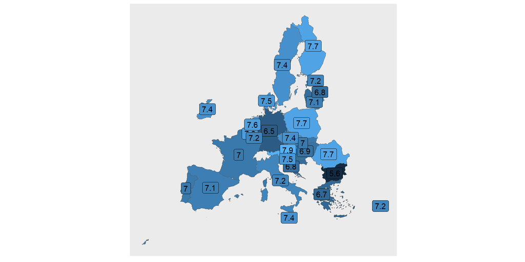

## Vragen en Discussie

- Wat is geluk volgens jullie?
- Zijn jullie gelukkig?

**Tip**

- Veel geluk!
- Gelukkig Koningsdag!
- Mijn geluk kan niet op!